# Pairing assessment

Table of Contents

Import datasets Select one entry per ICU stay in each method Estimate differences between Insulin timestamp and Glucose timestamp glucose 90 minutes glucose 60 minutes Paired glucose - no rules Hypothesis testing Time windows for scenario A

## Import datasets

Obtained from the 2.0-ara-pairing-II.ipynb notebook.

Open the CSV file on Microsoft's Excel and save it as a XLSX file.

```matlab
% Dataset curated and rules 90 min
% Columns: SUBJECT_ID, HADM_ID, ICUSTAY_ID, ICU_ADMISSIONTIME, ICU_DISCHARGETIME,
% LOS_ICU_days, first_ICU_stay, TIMER, STARTTIME, GLCTIMER, ENDTIME, INPUT,
% INPUT_HRS, INSULINTYPE, EVENT, GLC, GLCSOURCE, INFXSTOP, GLC_AL, GLCTIMER_AL,
% GLCSOURCE_AL, RULE, Repeated
BolusesCUR90 = importfile_BOLcur("BolusesCUR.xlsx", "BolusesCUR", [2, 88465]);

% Dataset curated and rules 60 min
% Columns: SUBJECT_ID, HADM_ID, ICUSTAY_ID, ICU_ADMISSIONTIME, ICU_DISCHARGETIME,
% LOS_ICU_days, first_ICU_stay, TIMER, STARTTIME, GLCTIMER, ENDTIME, INPUT,
% INPUT_HRS, INSULINTYPE, EVENT, GLC, GLCSOURCE, INFXSTOP, GLC_AL, GLCTIMER_AL,
% GLCSOURCE_AL, RULE, Repeated
BolusesCUR60 = importfile_bolus_cur_60("BolusesCUR_60.xlsx", "BolusesCUR_60", [2, 88465]);

% Dataset curated with no rules
% Columns: SUBJECT_ID, HADM_ID, ICUSTAY_ID, ICU_ADMISSIONTIME, ICU_DISCHARGETIME,
% LOS_ICU_days, first_ICU_stay, TIMER, STARTTIME, GLCTIMER, ENDTIME, INPUT,
% INPUT_HRS, INSULINTYPE, EVENT, GLC, GLCSOURCE, INFXSTOP, GLC_AL, GLCTIMER_AL,
% GLCSOURCE_AL, RULE, Repeated
BolusesCURnr = importfile_bolus_cur_nr("BolusesCUR_nr.xlsx", "BolusesCUR_nr", [2, 88465]);
```

## Select one entry per ICU stay in each method

```matlab
% Select first reading per method

uniqueICU = unique(BolusesCUR90.ICUSTAY_ID);

first_readings = array2table(nan(length(uniqueICU),18));
first_readings.Properties.VariableNames = {'ICUSTAY_ID',...
    'ICU_ADMISSIONTIME','ICU_DISCHARGETIME','LOS_min'...
    'STARTTIME','INPUT',...
    'GLC_AL90','GLCTIMER_AL90','GLCSOURCE_AL90','RULE90',...
    'GLC_AL60','GLCTIMER_AL60','GLCSOURCE_AL60','RULE60',...
    'GLC_ALnr','GLCTIMER_ALnr','GLCSOURCE_ALnr','RULEnr'};

for i=1:length(uniqueICU)
    ICUstay = uniqueICU(i);
    idx_nr = BolusesCURnr.ICUSTAY_ID == ICUstay;
    idx_90 = BolusesCUR90.ICUSTAY_ID == ICUstay;
    idx_60 = BolusesCUR60.ICUSTAY_ID == ICUstay;

    % ICU stay
    first_readings(i,'ICUSTAY_ID') = array2table(ICUstay);

    tbl_90 = BolusesCUR90(idx_90,:);
    tbl_90 = tbl_90(~any(ismissing(tbl_90,nan),2),:);

    tbl_60 = BolusesCUR60(idx_60,:);
    tbl_60 = tbl_60(~any(ismissing(tbl_60,nan),2),:);

    tbl_nr = BolusesCURnr(idx_nr,:);
    %tbl_nr = tbl_nr(~any(ismissing(tbl_nr,nan),2),:);

    % First insulin input
    insulin_row = topkrows(tbl_nr,1,{'STARTTIME'},'ascend');

    % Admission and discharge time
    first_readings(i, 'ICU_ADMISSIONTIME') = array2table(datenum(insulin_row.ICU_ADMISSIONTIME));

    % Discharge time
    first_readings(i,'ICU_DISCHARGETIME') = array2table(datenum(insulin_row.ICU_DISCHARGETIME));

    % Estimate LOS
    t1=table2array(insulin_row(:,{'ICU_DISCHARGETIME'}));
    t2=table2array(insulin_row(:,{'ICU_ADMISSIONTIME'}));
    dt_min=array2table(duration(time(between(t2,t1,'time')),'Format','m'), ...
        "VariableNames",{'LOS_min'});
    first_readings(i,'LOS_min') = array2table(minutes(dt_min.LOS_min));

    % Insulin
    first_readings(i,'STARTTIME') = array2table(datenum(insulin_row.STARTTIME));
    first_readings(i,"INPUT") = insulin_row(:,'INPUT');

    % No rules glucose data
    first_readings(i,"GLC_ALnr") = insulin_row(:,'GLC_AL');
    first_readings(i,"GLCSOURCE_ALnr") = insulin_row(:,"GLCSOURCE_AL");
    first_readings(i,'GLCTIMER_ALnr') = array2table(datenum(insulin_row.GLCTIMER_AL));
    first_readings(i,'RULEnr') = insulin_row(:,'RULE');

    % Indexes of i insulin input on tbl_60 and tbl_90
    idx_i90 = tbl_90.STARTTIME == insulin_row.STARTTIME;
    idx_i60 = tbl_60.STARTTIME == insulin_row.STARTTIME;

    if ~isempty(tbl_90(idx_i90,:))
        % 90 min
        if sum(idx_i90)>=2
            first_readings(i,"GLC_AL90") = tbl_90(find(idx_i90, 1 ),"GLC_AL");
            first_readings(i,"GLCSOURCE_AL90") = tbl_90(find(idx_i90, 1 ),'GLCSOURCE_AL');
            first_readings(i,'GLCTIMER_AL90') = array2table(datenum(table2array(tbl_90(find(idx_i90, 1 ),'GLCTIMER_AL'))));
            first_readings(i,'RULE90') = tbl_90(find(idx_i90, 1 ), 'RULE');
        else
            first_readings(i,"GLC_AL90") = tbl_90(idx_i90,'GLC_AL');
            first_readings(i,"GLCSOURCE_AL90") = tbl_90(idx_i90,'GLCSOURCE_AL');
            first_readings(i,'GLCTIMER_AL90') = array2table(datenum(table2array(tbl_90(idx_i90,'GLCTIMER_AL'))));
            first_readings(i,'RULE90') = tbl_90(idx_i90,'RULE');
        end
    else
        first_readings(i,"GLC_AL90") = array2table(nan);
    end

    if ~isempty(tbl_90(idx_i60,:))
        % 60 min
        if sum(idx_i60)>=2
            first_readings(i,"GLC_AL60") = tbl_60(find(idx_i60, 1 ),"GLC_AL");
            first_readings(i,"GLCSOURCE_AL60") = tbl_60(find(idx_i60, 1 ),'GLCSOURCE_AL');
            first_readings(i,'GLCTIMER_AL60') = array2table(datenum(table2array(tbl_60(find(idx_i60, 1 ),'GLCTIMER_AL'))));
            first_readings(i,'RULE60') = tbl_60(find(idx_i60, 1 ), 'RULE');
        else
            first_readings(i,"GLC_AL60") = tbl_60(idx_i60,'GLC_AL');
            first_readings(i,"GLCSOURCE_AL60") = tbl_60(idx_i60,'GLCSOURCE_AL');
            first_readings(i,"GLCTIMER_AL60") = array2table(datenum(table2array(tbl_60(idx_i60,'GLCTIMER_AL'))));
            first_readings(i,"RULE60") = tbl_60(idx_i60,'RULE');
        end
    else
        first_readings(i,"GLC_AL60") = array2table(nan);
    end
end
```

### Estimate differences between Insulin timestamp and Glucose timestamp

```matlab
first_readings = sortrows(first_readings,'INPUT','ascend');

first_readings(:,'dt_nr') = array2table(abs(datetime(table2array(first_readings(:,'STARTTIME')),'ConvertFrom','datenum') - ...
    datetime(table2array(first_readings(:,'GLCTIMER_ALnr')),'ConvertFrom','datenum')));
disp(['\Delta time insulin - glucose reading (no rules)',newline,...
    'Mean: ',num2str(minutes(mean(first_readings.dt_nr,'omitnan')),'%0.2f'),' +/- ',...
    num2str(minutes(std(first_readings.dt_nr,'omitnan')),'%0.2f'),' min']);
```

\Delta time insulin - glucose reading (no rules) Mean: 86.58 +/- 362.15 min

```matlab
first_readings(:,'dt_90') = array2table(abs(datetime(table2array(first_readings(:,'STARTTIME')),'ConvertFrom','datenum') - ...
    datetime(table2array(first_readings(:,'GLCTIMER_AL90')),'ConvertFrom','datenum')));
disp(['\Delta time insulin - glucose reading (90 min)',newline,...
    'Mean: ',num2str(minutes(mean(first_readings.dt_90,'omitnan')),'%0.2f'),...
    ' +/- ',num2str(minutes(std(first_readings.dt_90,'omitnan')),'%0.2f'),' min']);
```

\Delta time insulin - glucose reading (90 min) Mean: 26.75 +/- 23.16 min

```matlab
first_readings(:,'dt_60') = array2table(abs(datetime(table2array(first_readings(:,'STARTTIME')),'ConvertFrom','datenum') - ...
    datetime(table2array(first_readings(:,'GLCTIMER_AL60')),'ConvertFrom','datenum')));
disp(['\Delta time insulin - glucose reading (60 min)',newline,...
    'Mean: ',num2str(minutes(mean(first_readings.dt_60,'omitnan')),'%0.2f'),...
    ' +/- ',num2str(minutes(std(first_readings.dt_60,'omitnan')),'%0.2f'),' min']);
```

\Delta time insulin - glucose reading (60 min) Mean: 22.01 +/- 18.02 min

### Δglucose 90 minutes

```matlab
first_readings(:,'dg_90') = array2table(abs(first_readings.GLC_ALnr - first_readings.GLC_AL90));
first_readings(isnan(first_readings.dg_90),'dg_90') = first_readings(isnan(first_readings.dg_90),'GLC_ALnr');
first_readings(isnan(first_readings.dg_90),"dg_90") = first_readings(isnan(first_readings.dg_90),'GLC_AL90');

disp(['Paired glucose (90 min)',newline,'Mean: ',num2str(mean(first_readings.GLC_AL90,'omitnan'),'%0.2f'),...
    ' +/- ',num2str(std(first_readings.GLC_AL90,'omitnan'),'%0.2f'),' mg/dL']);
```

Paired glucose (90 min) Mean: 192.51 +/- 66.07 mg/dL

```matlab
disp(['\Delta glucose 90 min - no rules',newline,'Mean: ',...
    num2str(mean(first_readings.dg_90,'omitnan'),'%0.2f'),...
    ' +/- ',num2str(std(first_readings.dg_90,'omitnan'),'%0.2f'),...
    ' mg/dL',newline,'NO paired in both scenarios: ',...
    num2str(sum(isnan(first_readings.dg_90)))]);
```

\Delta glucose 90 min - no rules Mean: 26.25 +/- 62.57 mg/dL NO paired in both scenarios: 861

### Δglucose 60 minutes

```matlab
first_readings(:,'dg_60') = array2table(abs(first_readings.GLC_ALnr - first_readings.GLC_AL60));
first_readings(isnan(first_readings.dg_60),'dg_60') = first_readings(isnan(first_readings.dg_60),'GLC_ALnr');
first_readings(isnan(first_readings.dg_60),"dg_60") = first_readings(isnan(first_readings.dg_60),'GLC_AL60');

disp(['Paired glucose (60 min)',newline,...
    'Mean: ',num2str(mean(first_readings.GLC_AL60,'omitnan'),'%0.2f'),...
    ' +/- ',num2str(std(first_readings.GLC_AL60,'omitnan'),'%0.2f'),' min']);
```

Paired glucose (60 min) Mean: 191.51 +/- 65.40 min

```matlab
disp(['\Delta glucose 60 min - no rules',newline,'Mean: ',...
    num2str(mean(first_readings.dg_60,'omitnan'),'%0.2f'),...
    ' +/- ',num2str(std(first_readings.dg_60,'omitnan'),'%0.2f'),...
    ' mg/dL', newline,...
    'NO paired in both scenarios: ', num2str(sum(isnan(first_readings.dg_60)))]);
```

\Delta glucose 60 min - no rules Mean: 43.72 +/- 81.57 mg/dL NO paired in both scenarios: 877

### Paired glucose - no rules

```matlab
disp(['Paired glucose (no rules)',newline,'Mean: ',num2str(mean(first_readings.GLC_ALnr,'omitnan'),'%0.2f'),...
    ' +/- ',num2str(std(first_readings.GLC_ALnr,'omitnan'),'%0.2f'),' mg/dL']);
```

Paired glucose (no rules) Mean: 186.85 +/- 65.29 mg/dL

Histograms of time gaps between glucoe reading and insulin event

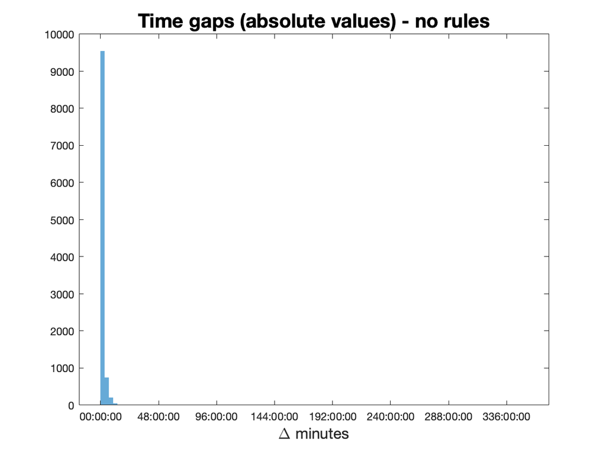

```matlab
histogram(first_readings.dt_nr,100,'EdgeAlpha',0);
title('Time gaps (absolute values) - no rules','FontSize',18)
xlabel('\Delta minutes', 'FontSize',14)
```

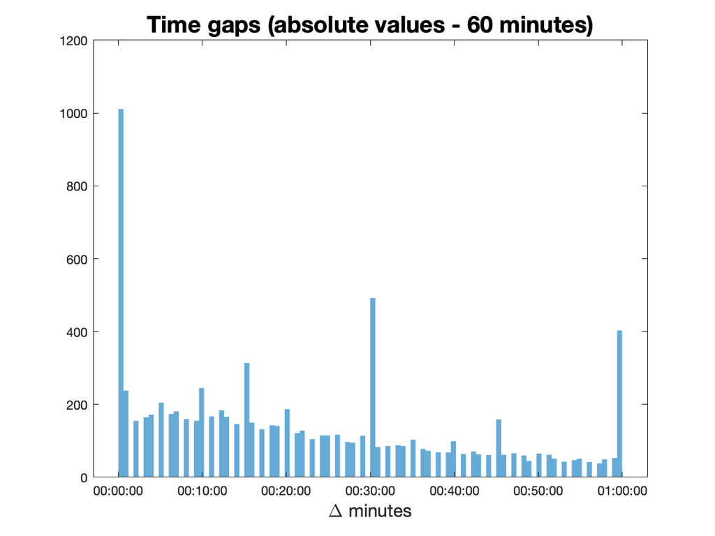

```matlab
histogram(first_readings.dt_60,100,'EdgeAlpha',0);
title('Time gaps (absolute values - 60 minutes)','FontSize',18)
xlabel('\Delta minutes', 'FontSize',14)
```

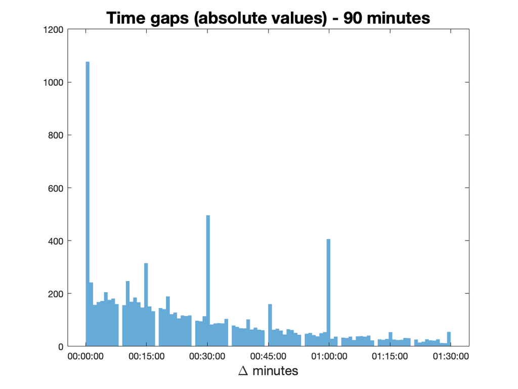

```matlab
histogram(first_readings.dt_90,100,'EdgeAlpha',0);
title('Time gaps (absolute values) - 90 minutes','FontSize',18)
xlabel('\Delta minutes', 'FontSize',14)
```

## Hypothesis testing

Wilcoxon Signed Rank Test

It is a nonparametric test for two populations when the observations are paired. In this case, the test statistic, W, is the sum of the ranks of positive differences between the observations in the two samples (that is, x – y). When you use the test for one sample, then W is the sum of the ranks of positive differences between the observations and the hypothesized median value .

```matlab
% Replace missing values in dt_nr for values in dt_90
% Values that were not paired with no rules
first_readings(:,'A') = first_readings(:,'dt_nr');
first_readings(isnan(first_readings.dt_nr),'A') = first_readings(isnan(first_readings.dt_nr),'dt_90');
disp(['Values that were not paired with no rules but paired in scenario A: ', ...
    num2str(sum(table2array(first_readings(isnan(first_readings.dt_nr),'dt_90'))>0))])
```

Values that were not paired with no rules but paired in scenario A: 24

```matlab
% Replace missing values in dt_nr for values in dt_60
% Values that were not paired with no rules
first_readings(:,'B') = first_readings(:,'dt_nr');
first_readings(isnan(first_readings.dt_nr),'B') = first_readings(isnan(first_readings.dt_nr),'dt_60');
disp(['Values that were not paired with no rules but paired in scenario B: ', ...
    num2str(sum(table2array(first_readings(isnan(first_readings.dt_nr),'dt_60'))>0))])
```

Values that were not paired with no rules but paired in scenario B: 17

```matlab
% Difference only between glucose readings
% Whole array
[h,p,~,stats] = ttest(table2array(first_readings(~isnan(first_readings.dg_90),'dg_90')));
disp(['[Glucose fingerstick] - [Glucose serum]',newline,'Rejects Ho at the 5% significance level: ', ...
    num2str(h),', p-value = ', num2str(p,'%0.2e'),', t statistic = ', num2str(stats.tstat,'%0.2f')])
```

[Glucose fingerstick] - [Glucose serum] Rejects Ho at the 5% significance level: 1, p-value = 0.00e+00, t statistic = 43.24

### Time windows for scenario A

```matlab
% 90 minutes
theta_array = [30 60 90 120];

CIdata = nan(5,length(theta_array)+1);

d_glc = first_readings.dg_90;

for i=1:(length(theta_array)+1)
    if i==1
        theta1 = minutes(0);
        theta2 = minutes(theta_array(i));
    else
        if i==(length(theta_array)+1)
            theta1 = minutes(theta_array(i-1));
            theta2 = minutes(max(first_readings.A)+minutes(1));
        else
            theta1 = minutes(theta_array(i-1));
            theta2 = minutes(theta_array(i));
        end
    end
    theta = ((first_readings.A)>=theta1)&((first_readings.A)<theta2);

    % Paired Wilcoxon rank test
    % Within +/- theta min
    [p,h,stats] = signrank(d_glc(theta));
    disp('Wilcoxon rank test')
    disp(['[Glucose nr] - [Glucose 90] within ',...
        char(theta1),'-',char(theta2),' min',newline,...
        'Rejects Ho at the 5% significance level: ', ...
        num2str(h),newline,'p-value = ', num2str(p,'%0.2e'),...
        ', W statistic = ', num2str(stats.signedrank,'%0.2f'), newline])
    disp(['Mean: ',num2str(mean(d_glc(theta)),...
        '%0.2f'),' +/- ',...
        num2str(std(d_glc(theta)),...
        '%0.2f'),newline]);
    disp(['Median: ', num2str(median(d_glc(theta)))]);
    disp(['Q1: ', num2str(quantile(d_glc(theta),0.25)), ...
        newline, ...
        'Q3: ', num2str(quantile(d_glc(theta),0.75)),newline]);
    N = length(d_glc(theta));
    disp(['Entries for ',char(theta1),'-',char(theta2),': ', ...
        num2str(N),newline,...
        num2str((N/(length(d_glc))*100),2),...
        '% of total entries',newline,' '])

    % Compute ‘Standard Error Of The Mean’ Of
    % All Experiments At Each time gap
    ySEM = std(d_glc(theta))/sqrt(N);

    % Calculate 95% Probability Intervals Of
    % t-Distribution
    CI95 = tinv([0.025 0.975], N-1);

    % Calculate 95% Confidence Intervals Of
    % All Experiments At Each time gap
    yCI95 = bsxfun(@times, ySEM, CI95(:));

    % Allocate data
    CIdata(1:2,i) = yCI95;
    % Mean
    CIdata(3,i) = mean(d_glc(theta));
    % SD
    CIdata(4,i) = std(d_glc(theta));
    % N
    CIdata(5,i) = N;
end
```

Wilcoxon rank test

[Glucose nr] - [Glucose 90] within 0 min-30 min min Rejects Ho at the 5% significance level: 1 p-value = 1.15e-28, W statistic = 13530.00

Mean: 2.17 +/- 16.77

Median: 0

Q1: 0 Q3: 0

Entries for 0 min-30 min: 4468 39% of total entries

Wilcoxon rank test

[Glucose nr] - [Glucose 90] within 30 min-60 min min Rejects Ho at the 5% significance level: 1 p-value = 3.93e-31, W statistic = 16110.00

Mean: 2.36 +/- 13.48

Median: 0

Q1: 0 Q3: 0

Entries for 30 min-60 min: 2548 22% of total entries

Wilcoxon rank test

[Glucose nr] - [Glucose 90] within 60 min-90 min min Rejects Ho at the 5% significance level: 1 p-value = 1.19e-29, W statistic = 14535.00

Mean: 4.46 +/- 16.58

Median: 0

Q1: 0 Q3: 0

Entries for 60 min-90 min: 1313 11% of total entries

Wilcoxon rank test

[Glucose nr] - [Glucose 90] within 90 min-120 min min Rejects Ho at the 5% significance level: 1 p-value = 4.11e-76, W statistic = 103285.00

Mean: 143.45 +/- 97.15

Median: 157.5

Q1: 44 Q3: 195

Entries for 90 min-120 min: 502 4.4% of total entries

Wilcoxon rank test

[Glucose nr] - [Glucose 90] within 120 min-劸 min Rejects Ho at the 5% significance level: 1 p-value = 3.36e-292, W statistic = 1583310.00

Mean: 103.39 +/- 83.72

Median: 86

Q1: 29 Q3: 166

Entries for 120 min-劸: 1792 16% of total entries

```matlab
% 60 minutes
CIdata2 = nan(5,length(theta_array)+1);

d_glc = first_readings.dg_60;

for i=1:(length(theta_array)+1)
    if i==1
        theta1 = minutes(0);
        theta2 = minutes(theta_array(i));
    else
        if i==(length(theta_array)+1)
            theta1 = minutes(theta_array(i-1));
            theta2 = minutes(max(first_readings.A)+minutes(1));
        else
            theta1 = minutes(theta_array(i-1));
            theta2 = minutes(theta_array(i));
        end
    end
    theta = (abs(first_readings.B)>=theta1)&(abs(first_readings.B)<theta2);

    % Paired Wilcoxon rank test
    % Within +/- theta min
    [p,h,stats] = signrank(d_glc(theta));
    disp('Wilcoxon rank test')
    disp(['[Glucose nr] - [Glucose 60] within ',...
        char(theta1),'-',char(theta2),' min',newline,...
        'Rejects Ho at the 5% significance level: ', ...
        num2str(h),newline,'p-value = ', num2str(p,'%0.2e'),...
        ', W statistic = ', num2str(stats.signedrank,'%0.2f')])
    disp(['Mean: ',num2str(mean(d_glc(theta)),...
        '%0.2f'),' +/- ',...
        num2str(std(d_glc(theta)),...
        '%0.2f'),newline]);
    disp(['Median: ', num2str(median(d_glc(theta)))]);
    disp(['Q1: ', num2str(quantile(d_glc(theta),0.25)), ...
        newline, ...
        'Q3: ', num2str(quantile(d_glc(theta),0.75)),newline]);
    N = length(d_glc(theta));
    disp(['Entries for ',char(theta1),'-',char(theta2),': ', ...
        num2str(N),newline,...
        num2str((N/(length(d_glc))*100),2),...
        '% of total entries',newline,' '])

    % Compute ‘Standard Error Of The Mean’ Of
    % All Experiments At Each time gap
    ySEM = std(d_glc(theta))/sqrt(N);

    % Calculate 95% Probability Intervals Of
    % t-Distribution
    CI95 = tinv([0.025 0.975], N-1);

    % Calculate 95% Confidence Intervals Of
    % All Experiments At Each time gap
    yCI95 = bsxfun(@times, ySEM, CI95(:));

    % Allocate data
    CIdata2(1:2,i) = yCI95;
    % Mean
    CIdata2(3,i) = mean(d_glc(theta));
    % SD
    CIdata2(4,i) = std(d_glc(theta));
    % N
    CIdata2(5,i) = N;
end
```

Wilcoxon rank test

[Glucose nr] - [Glucose 60] within 0 min-30 min min Rejects Ho at the 5% significance level: 1 p-value = 2.28e-26, W statistic = 11325.00

Mean: 1.61 +/- 13.12

Median: 0

Q1: 0 Q3: 0

Entries for 0 min-30 min: 4454 39% of total entries

Wilcoxon rank test

[Glucose nr] - [Glucose 60] within 30 min-60 min min Rejects Ho at the 5% significance level: 1 p-value = 5.74e-31, W statistic = 15931.00

Mean: 2.28 +/- 12.78

Median: 0

Q1: 0 Q3: 0

Entries for 30 min-60 min: 2547 22% of total entries

Wilcoxon rank test

[Glucose nr] - [Glucose 60] within 60 min-90 min min Rejects Ho at the 5% significance level: 1 p-value = 1.25e-153, W statistic = 431985.00

Mean: 132.17 +/- 106.97

Median: 157

Q1: 0 Q3: 196

Entries for 60 min-90 min: 1312 11% of total entries

Wilcoxon rank test

[Glucose nr] - [Glucose 60] within 90 min-120 min min Rejects Ho at the 5% significance level: 1 p-value = 5.95e-84, W statistic = 126253.00

Mean: 172.74 +/- 86.09

Median: 171.5

Q1: 137 Q3: 210

Entries for 90 min-120 min: 502 4.4% of total entries

Wilcoxon rank test

[Glucose nr] - [Glucose 60] within 120 min-劸 min Rejects Ho at the 5% significance level: 1 p-value = 3.36e-292, W statistic = 1583310.00

Mean: 106.41 +/- 84.34

Median: 94

Q1: 31 Q3: 169

Entries for 120 min-劸: 1792 16% of total entries

In the last time-gaps, there are 13 instances where the value of the first glucose reading in either scenario A and B is exactly the same nominal value in scenario C. But time-stamps are different. Therefore, it will not be considered these instances for counting the values that were matched.

CI plot for each time-gap

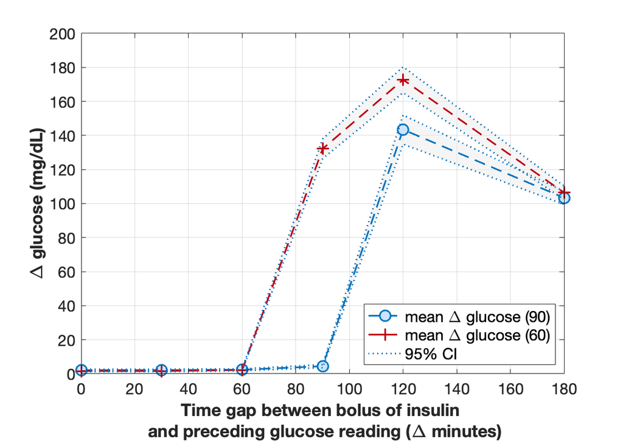

```matlab
CIplot = horzcat(CIdata(1:3,1),CIdata(1:3,:));
CIplot2 = horzcat(CIdata2(1:3,1),CIdata2(1:3,:));
theta_plot = horzcat(0,theta_array,theta_array(end)+60);
x2 = [theta_plot, fliplr(theta_plot)];
tmp = CIplot(1:2,:)+CIplot(3,:);
tmp2 = CIplot2(1:2,:)+CIplot2(3,:);
inBetween = [tmp(1,:), fliplr(tmp(2,:))];
inBetween2 = [tmp2(1,:), fliplr(tmp2(2,:))];

figure
h = fill(x2, inBetween, [0.9 0.9 0.9]);
set(h,'facealpha',0.4)
set(h,'EdgeAlpha',0)
set(get(get(h,'Annotation'),'LegendInformation'),'IconDisplayStyle','off');
hold on
f = fill(x2, inBetween2, [0.9 0.9 0.9]);
set(f,'facealpha',0.4)
set(f,'EdgeAlpha',0)
set(get(get(f,'Annotation'),'LegendInformation'),'IconDisplayStyle','off');
plot(theta_plot, CIplot(3,:),'--o','MarkerSize',10,...
    'MarkerFaceColor','#CCE5FF',...
    'LineWidth',1.5,'DisplayName','mean \Delta glucose (90)',...
    "Color",'#0072BD')
plot(theta_plot, CIplot2(3,:),'--+','MarkerSize',10,...
    'MarkerFaceColor','#e38fa3',...
    'LineWidth',1.5,'DisplayName','mean \Delta glucose (60)',...
    "Color",'#bd0013')
g = plot(theta_plot, CIplot(1:2,:)+CIplot(3,:),':',...
    'DisplayName','95% CI','Color',[0 0.4470 0.7410],...
    'LineWidth',1.5);
set(get(get(g(2),'Annotation'),'LegendInformation'),'IconDisplayStyle','off');
k = plot(theta_plot, CIplot2(1:2,:)+CIplot2(3,:),':',...
    'Color',[0 0.4470 0.7410],'LineWidth',1.5);
set(get(get(k(1),'Annotation'),'LegendInformation'),'IconDisplayStyle','off');
set(get(get(k(2),'Annotation'),'LegendInformation'),'IconDisplayStyle','off');
hold off
grid
xlabel(['Time gap between bolus of insulin ',newline,' and preceding glucose reading (\Delta minutes)'],"FontSize",16, "FontWeight","bold")
ylabel('\Delta glucose (mg/dL)', 'FontSize',16, "FontWeight","bold")
legend('FontSize', 14,'Location','southeast')
ax = gca;
ax.FontSize = 14;
fig = gcf;
fig.Units = "centimeters";
fig.Position(4) = 14;
```